# ESM 262 Assignment1

Sara Orofino

2/21/2020

## Load packages

```r
library(tidyverse)
library(RColorBrewer)
library(here)
```

## Function

This function was designed to calculate a theoretical equal share of FEMA funding for every federally declared disaster in Puerto Rico from 2001-2018. The theoretical equal share is the per capita FEMA funding that each municipality included in the disaster should have gotten if all the funding was allocated equally. The function has four inputs:

- disasters: a vector of character strings corresponding to the column names in the input data where the inclusion information is stored
  - Inclusion information must be binary (0 = not included, 1 = included)
- fund1: a vector of character strings corresponding to the column names in the input data where one type of funding information is stored
- fund2: a vector of character strings corresponding to the column names in the input data where a second type of funding information is stored
- input_df: the data frame containing all the values for the other three inputs plus population data for each municipality

## Data

Generate data the function using two different methods

**Method 1**  
*Load a data file*

```r
# Load the data:
fema <- read_csv(file.path(here(), "assignments/assignment1/combined_fema_funding.csv"))

# Using the data file assign the correct column headings to vectors to make the other three inputs:
disaster_numbers <- colnames(fema[5:17]) #colnames for inclusion data
pa_funding <- colnames(fema[,18:30]) #colnames for public assistance funding data
hmgp_funding <- colnames(fema[31:43]) #colnames for hazard grant mitigation program data
```

**Method 2**  
*Create the input data*

Simulate 5 disasters in the 78 municipalities - create a data frame with the following information:  
- population  
- inclusion (binary 0/1)  
- funding (2 types)

```r
#Start with any empty df with 78 rows for the different municipalities and 16 columns:
method2 <- setNames(data.frame(matrix(nrow = 78, ncol = 16)),
                      c("totpop", "dist1", "dist2", "dist3", "dist4", "dist5",
                        "fund1_1", "fund1_2", "fund1_3", "fund1_4", "fund1_5",
                        "fund2_1", "fund2_2", "fund2_3", "fund2_4", "fund2_5"))

#Generate population data (assume a wide range of sizes maybe 1500 to 100,000 but all equally likely)
method2$totpop <- runif(78, 1500, 100000)

#Generate inclusion data (0 = not included, 1 = included):
method2$dist1 <- rbinom(78, 1, 0.5)
method2$dist2 <- rbinom(78, 1, 0.5)
method2$dist3 <- rbinom(78, 1, 0.5)
method2$dist4 <- rbinom(78, 1, 0.5)
method2$dist5 <- rbinom(78, 1, 0.5)

# Generate funding data (millions) - most funding is between 1 and 2 million:
method2$fund1_1 <- runif(78,0,2)
method2$fund1_2 <- runif(78,0,2)
method2$fund1_3 <- runif(78,0,2)
method2$fund1_4 <- runif(78,0,2)
method2$fund1_5 <- runif(78,0,2)
method2$fund2_1 <- runif(78,0,2)
method2$fund2_2 <- runif(78,0,2)
method2$fund2_3 <- runif(78,0,2)
method2$fund2_4 <- runif(78,0,2)
method2$fund2_5 <- runif(78,0,2)

# Vector of names for the function inputs:
dist_nums <- colnames(method2[2:6])
funding_1 <- colnames(method2[7:11])
funding_2 <- colnames(method2[12:16])
```

## Run Function

```r
# Source the function from the .R file
source("equal_share.R")

# Method 1:
es_method1 <- equal_share(disasters = disaster_numbers, fund1 = pa_funding,
                          fund2 = hmgp_funding, input_df = fema)

# Method 2:
es_method2 <- equal_share(disasters = dist_nums, fund1 = funding_1,
                          fund2 = funding_2, input_df = method2)
```

## Graphs

Graph of results (using method 1)

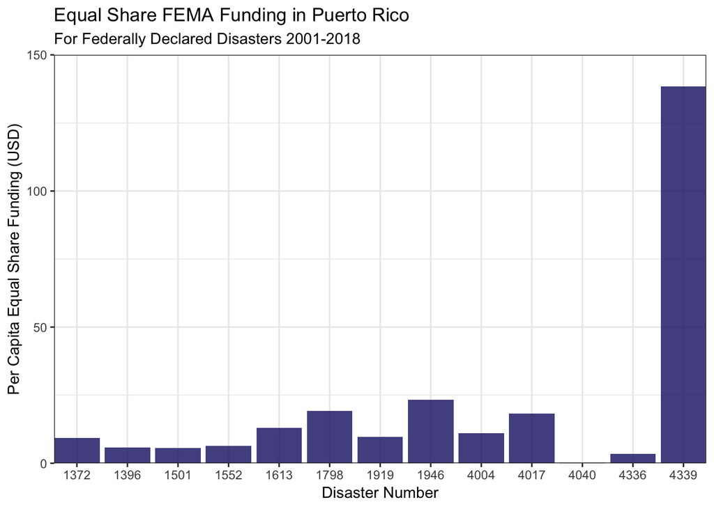

The graph above shows the theoretical per capita equal share of FEMA funding for all federally declared disasters in Puerto Rico between 2001 and 2018. The equal share calculation is based on the number of municipalities included in the declaration and sums all the FEMA funding recieved after the disaster split by the total population of the included municipalities. Most of the disasters have a fairly low (below $25) per capita equal share. On the two extremes, disaster 4040 (Tropical Storm Maria) had a per capita equal share of less than $1 and disaster 4339 (Hurricane Maria) had a per capita equal share of nearly $140. Tropical Storm Maria quickly progressed to a severe Category 5 hurricane for which a separate federal disaster declaration was made. Damages from Tropical Storm Maria were most likely made worse after Hurricane Maria and municipalities probably applied for funding to help with those damages after the hurricane. This may explain why the overall funding, and consequently the per capita equal share, for Tropical Storm Maria was so low.

The project for which this function has been created calculates the damages from Hurricane Maria and the time to recover different proportions of economic activity. An actual share calculation shows how much per capita funding each municipality recieved after each disaster which can be compared to the theoretical equal share. For Hurricane Maria, these numbers are also compared to monetary damages within each municipality to look for patterns in FEMA funding allocation and to explore if damages or funding can explain the differences in recovery time across municipalities.